# Muestras de café de Coffee Quality Institute (CQI)

Kevin Córdoba

2023-05-29

### Introducción

El Coffee Quality Institute (CQI) es una organización sin fines de lucro con sede en California, Estados Unidos, que se dedica a mejorar la calidad y el valor del café a nivel mundial. Desde su fundación en 1996, el CQI ha trabajado incansablemente para promover estándares de calidad en la industria del café a través de investigaciones, programas de capacitación y certificación. El CQI colabora estrechamente con productores, procesadores, tostadores y otros actores de la cadena de suministro del café para mejorar la calidad del café, fomentar la sostenibilidad y apoyar el crecimiento de la industria del café de especialidad.

Como parte de su labor, el CQI mantiene una valiosa base de datos en línea que proporciona información y recursos a profesionales y entusiastas del café interesados en aprender sobre la calidad y la sostenibilidad del café. Esta base de datos abarca temas como la producción de café, el procesamiento y la evaluación sensorial, y también ofrece datos sobre genética del café, tipos de suelo y otros factores que influyen en la calidad del café. En cuanto a la evaluación de la calidad del café, el CQI utiliza una serie de criterios sensoriales para evaluar y puntuar el café. Estos criterios incluyen el aroma, el sabor, el regusto, la acidez, el cuerpo, el equilibrio, la uniformidad, la limpieza de taza y la dulzura. Estas evaluaciones permiten identificar los perfiles sensoriales de los distintos cafés y garantizar una experiencia de consumo de alta calidad.

El CQI también se dedica a estudiar y abordar los defectos que pueden afectar el café. Estos defectos se clasifican en dos categorías: defectos de categoría uno, que son detectables visualmente, y defectos de categoría dos, que solo se pueden percibir mediante la degustación. Al comprender y abordar estos defectos, el CQI contribuye a mejorar la calidad general del café y a eliminar características indeseables en los granos.

### Carga de Datos y Paquetes

```r
# Carga de paquetes de R
library(dplyr)
library(ggplot2)
library(plotly)
library(DT)
library(sf)
library(terra)
library(raster)
library(leaflet)
library(tidyverse)
library(readr)
```

```r
#Carga de datos
coffee_datos <-
  readr::read_csv("https://raw.githubusercontent.com/gf0604-procesamientodatosgeograficos/2023-i/main/datos/cqi/coffee-quality.csv",
    col_select = c(
      "Country_of_Origin",
      "Variety",
      "Color",
      "Altitude",
      "Total_Cup_Points"
    )
  )
```

### Tabla de Datos

```r
coffee_datos %>%
  dplyr::select(Country_of_Origin, Variety, Color, Altitude, Total_Cup_Points) %>%
  datatable(
    colnames = c("Country_of_Origin", "Variety", "Color", "Altitude", "Total_Cup_Points"),
    options = list(
      pageLength = 5,
      language = list(url = '//cdn.datatables.net/plug-ins/1.10.11/i18n/Spanish.json')
    )
  )
```

|  | Country_of_Origin | Variety | Color | Altitude | Total_Cup_Points |
| --- | --- | --- | --- | --- | --- |
| 1 | Taiwan | Gesha | blue-green | 1200 | 87.58 |
| 2 | Taiwan | Gesha | blue-green | 1060 | 85.5 |
| 3 | Taiwan | Yellow Bourbon | blue-green | 1200 | 84.75 |
| 4 | Indonesia | Jember,TIM-TIM,Ateng | blue-green | 1300 | 84.25 |
| 5 | Madagascar | Bourbon | blue-green | 1500 | 84.25 |
| 6 | Taiwan | Typica + SL34 | blue-green | 1100 | 83.42 |
| 7 | Taiwan | SL34 | blue-green | 750 | 83.33 |
| 8 | Taiwan | unknown | blue-green | 340 | 83.17 |
| 9 | Taiwan | Typica | blue-green | 275 | 82.92 |
| 10 | Taiwan | Caturra | blue-green | 465 | 82.58 |

[output cut: 196 more lines]

## Gráficos estadísticos

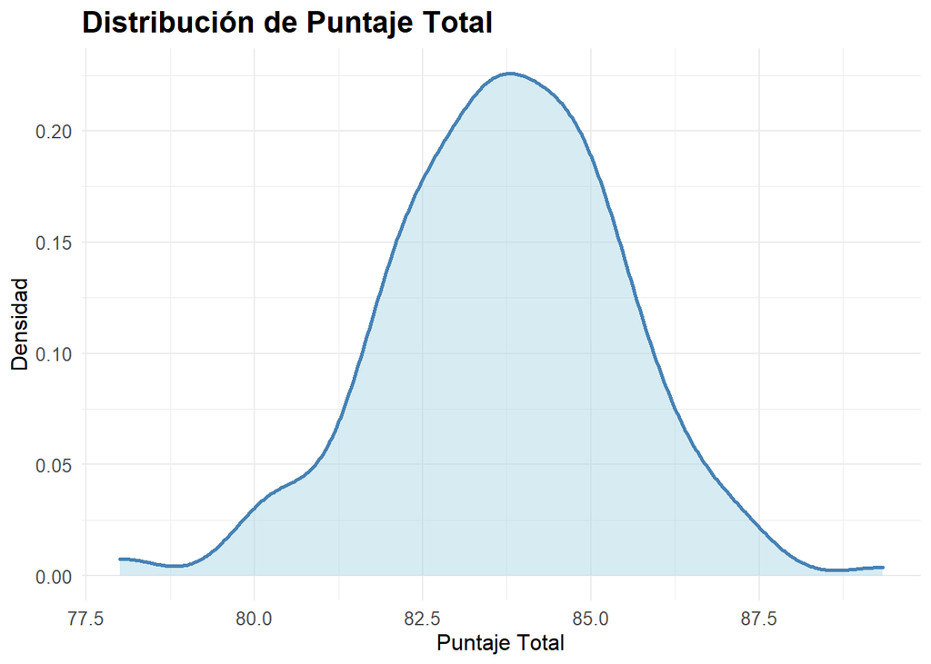

```r
coffee_datos %>%
  ggplot(aes(x = Total_Cup_Points)) +
  geom_density(
    color = "steelblue",
    fill = "lightblue",
    alpha = 0.5,
    size = 1
  ) +
  labs(
    title = "Distribución de Puntaje Total",
    x = "Puntaje Total",
    y = "Densidad"
  ) +
  theme_minimal() +
  theme(
    legend.position = "none",
    plot.title = element_text(size = 16, face = "bold"),
    axis.title = element_text(size = 12),
    axis.text = element_text(size = 10),
    axis.ticks = element_blank()
  )
```

### Gráfico de dispersión

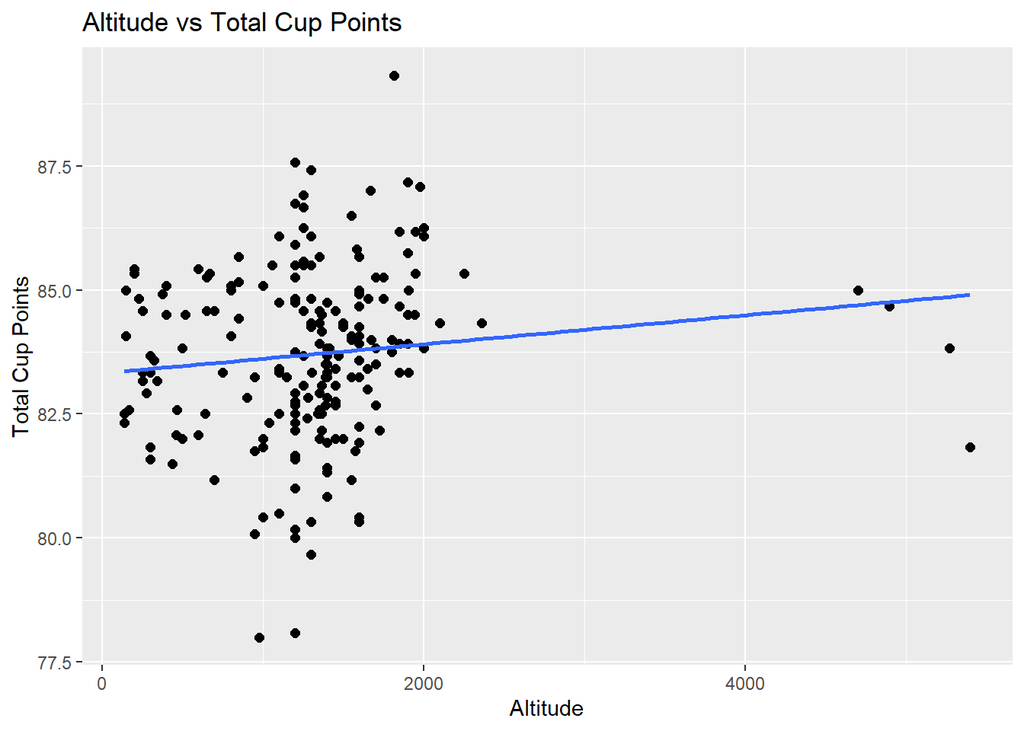

```r
coffee_datos %>%
  ggplot(aes(x = Altitude, y = Total_Cup_Points)) +
  geom_point(size = 2) +
  geom_smooth(method = "lm", se = FALSE) +
  ggtitle("Altitude vs Total Cup Points") +
  xlab("Altitude") +
  ylab("Total Cup Points") +
  labs(color = "Especie", shape = "Especie")
```

### Gráfico de caja

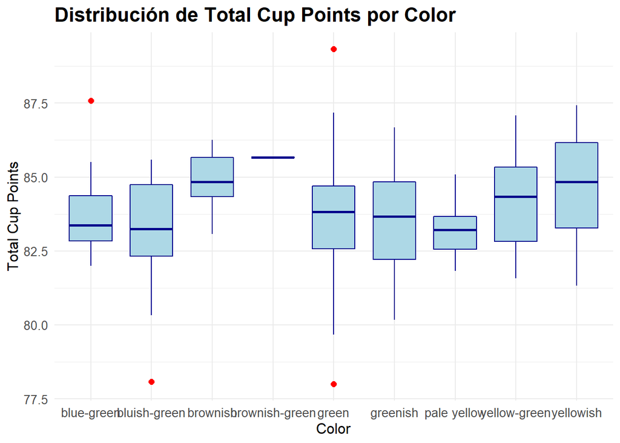

```r
coffee_datos %>%
  ggplot(aes(x = Color, y = Total_Cup_Points, fill = Color)) +
  geom_boxplot(
    color = "darkblue",
    fill = "lightblue",
    outlier.color = "red",
    outlier.shape = 16,
    outlier.size = 2,
    width = 0.7
  ) +
  labs(
    title = "Distribución de Total Cup Points por Color",
    x = "Color",
    y = "Total Cup Points"
  ) +
  theme_minimal() +
  theme(
    legend.position = "none",
    plot.title = element_text(size = 16, face = "bold"),
    axis.title = element_text(size = 12),
    axis.text = element_text(size = 10),
    axis.ticks = element_blank()
  )
```

### Bibliografía

Coffee Quality Institute provides coffee education throughout the coffee value chain. (2023). Coffeeinstitute.org. https://www.coffeeinstitute.org/